# frank_wang_homework4

Nathan Frank and Yen Wang

2/21/2022

## Team members: Yen Wang, Nathan Frank

link to github repo: https://github.com/natefrank48/lab2

### What is the overall number of chocolate bars rated? How does the number of ratings depend on the year? Draw a bar chart of the number of reports.

```r
choco = read.csv("choco.csv")
print(nrow(choco))
```

```
## [1] 1852
```

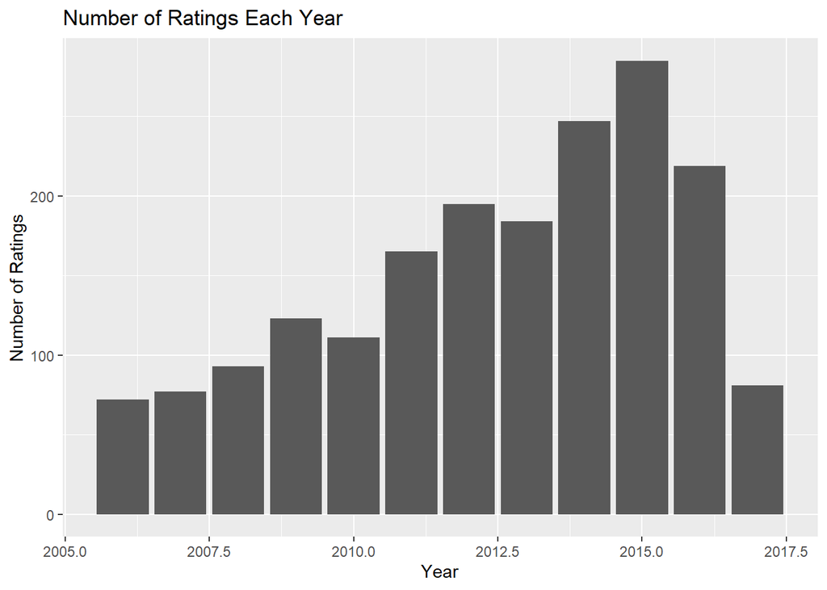

```r
ggplot(data = choco, aes(x = Review.Date)) + geom_bar() +
  xlab("Year") +
  ylab("Number of Ratings") +
  ggtitle("Number of Ratings Each Year")
```

### How are ratings distributed?

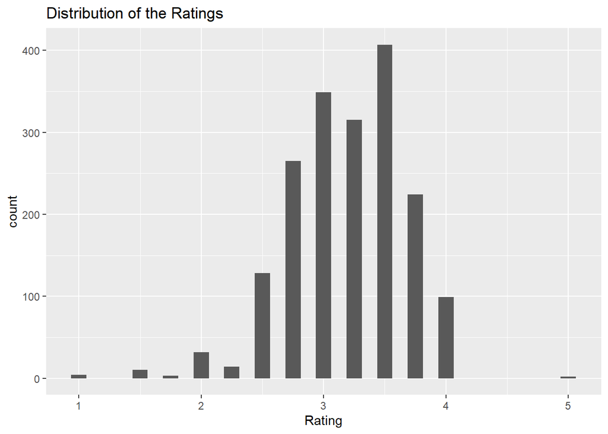

```r
ggplot(data = choco, aes(x = Rating)) +
  geom_histogram(bins = 33) +
  ggtitle("Distribution of the Ratings")
```

### Do ratings depend on the cocoa percentage of a chocolate bar?

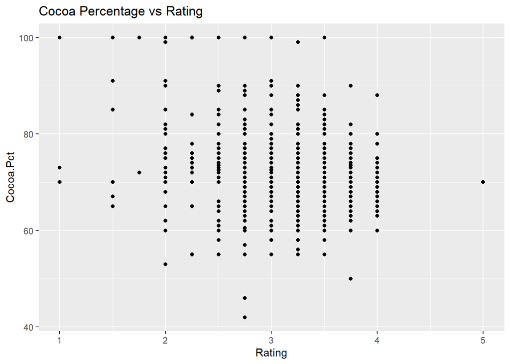

```r
ggplot(data = choco, aes(x = Rating, y = Cocoa.Pct)) +
  geom_point() +
  ggtitle("Cocoa Percentage vs Rating")
```

From the scatter plot above, we can conclude that the ratings do not depend on the coca percentage of a chocolate bar. Since the cocoa percentage of most chocolate is between 60 and 85 and the outliers’ ratings are also in that range.

### How do ratings compare across different company locations?

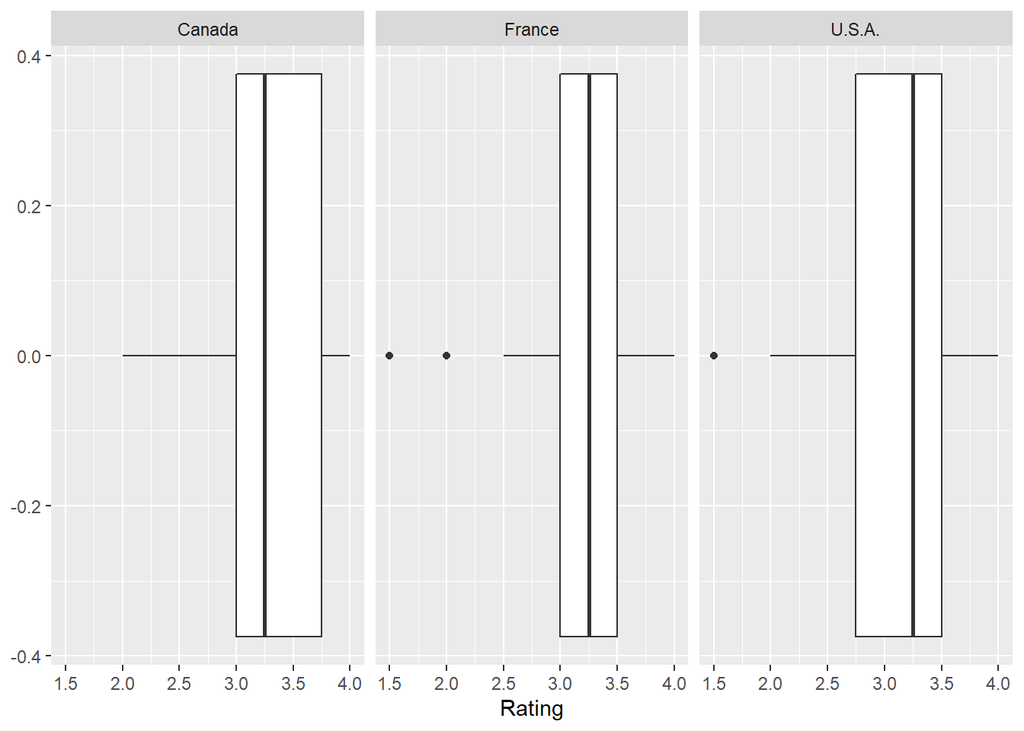

```r
choco2 = dplyr::filter(choco, Company.Location %in% c("U.S.A.", "France", "Canada"))
ggplot(data = choco2, aes(x=Rating)) + geom_boxplot() + facet_wrap(~Company.Location)
```

The box plots show that the median value of all 3 locations is almost exactly 3.25.Canada has a wider range of chocolates from the median to the upper quartile, while the U.S.A has a wider range from the median to the lower quartile. All the locations have a max value the is around 4.0.

### Of the three companies with the most rated chocolates, which has the highest ratings?

```r
compamy.num.ratings = choco %>% group_by(Company) %>% summarise(no_rows = length(Company))
head(compamy.num.ratings[order(compamy.num.ratings$no_rows, decreasing=TRUE),])
```

```
## # A tibble: 6 x 2
##   Company  no_rows
##   <chr>      <int>
## 1 Soma          47
## 2 Bonnat        27
## 3 Fresco        26
## 4 Pralus        25
## 5 A. Morin      23
## 6 Arete         22
```

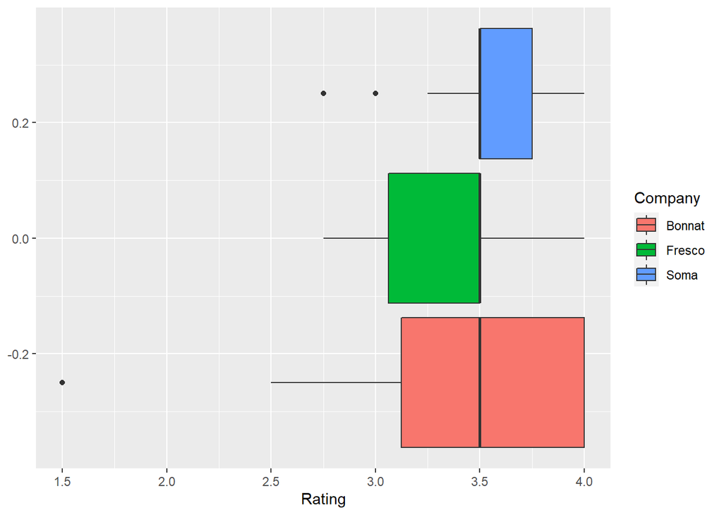

```r
choco3 = dplyr::filter(choco, Company %in% c("Soma", "Bonnat", "Fresco"))
ggplot(data = choco3, aes(x=Rating, fill=Company)) + geom_boxplot()
```

All three of the companies with the most chocolate rated had a median value around 3.5. Soma has the largest percentage of their chocolate at or above a 3.5. However, Bonnat has the highest upper quartile, meaning they have a larger percentage of their chocolate with a rating of 4.

# Work distrubution:

Since Question set I was discussed in class already, we decided to split the rest of the problems, where we each do two. I will be doing the first two problems from question set ii and Nathan will do the third problem and write his own question.